# In-term II, M362M Fall 2024

*Instructions*:

- Problem 1 is “theoretical” - its solution can be submitted as a pdf scan of one or more hand-written pages (or knitted Rmds if you know LaTeX). You are not allowed to use R (or any other software, or a calculator) for it. In particular, no simulations.
- Problem 2 is computational - submit its solution in pdf (knitted from Rmd) just like you would submit your HW. Make sure to **submit the Rmd file you used to knit the pdf**. Submitting only the pdf file will result in a 50% penalty.
- If you have any questions, please post them on Ed Discussion.

## Problem 1.

Let $\{X_n\}_{n\in {\mathbb N}_0}$ be a simple symmetric random walk.

1. (*5 pts*) What is the probability that $X_{11}=5$?
2. (*10 pts*) What is the probability that $X$ will reach the level $5$ before (or at) time $n=11$?
3. (*15 pts*) What is the probability that $X$ will reach the level $5$ before (or at) time $n=11$, if it is known that $X_3=3$?
4. (*20 pts*) What is the probability that $X$ will reach the level $5$ before (or at) time $n=11$, if it is known that it will not reach the level $6$ before (or at) time $n=11$?

*Note:* You don’t have to evaluate binomial coefficients.

## Solution

1. This is given by the usual formula
   $$\begin{align}
   {\mathbb P}[ X_{11} = 5] = 2^{-11} \binom{11}{8}
   \end{align}$$
2. This is the same as the probability that the running maximum at time $n=11$ takes the value $5$ of higher. By the formula from the notes,
   $$\begin{align}
   {\mathbb P}[ M_{11} \geq 5] &= {\mathbb P}[ X_{11}=5] + 2 {\mathbb
   P}[ X_{11}=7] +
   2 {\mathbb P}[ X_{11} = 9] + 2{\mathbb P}[X_{11}=11]\\
   &= 2^{-11} \left( \binom{11}{8} + 2 \binom{11}{9} + 2\binom{11}{10}
   + 2 \binom{11}{11}\right)
   \end{align}$$
3. We need to look at the random walk $Y_n = X_{3+n} - 3$ and find the probability that it will hit the level $2$ before (or at) time $n=8$. This is equivalent to the probability that the ${\mathbb P}[ M_8 \geq 2]$, where $M$ is the running-maximum process of a SSRW. According to the formula from the notes, we have
   $$\begin{align}
   {\mathbb P}[ M_8 \geq 2] &= 1 - {\mathbb P}[ M_8 = 1] - {\mathbb P}[
   M_8=0]
   = 1 - {\mathbb P}[ X_8=2] - {\mathbb P}[ X_8=0] \\
   &= 1 - 2^{-8} \left( \binom{8}{5} + \binom{8}{4} \right).
   \end{align}$$
4. This is the conditional probability
   $$\begin{align}
   {\mathbb P}[ M_11 \geq 5 | M_{11} < 6] & =
   \frac{{\mathbb P}[ M_{11} \geq 5 \text{ and } M_{11}<6]}{{\mathbb P}[
   M_{11} < 6]}
   = \frac{ {\mathbb P}[ M_{11} = 5]}{ {\mathbb P}[ M_{11} \leq 5]}
   \\ & = \frac{ {\mathbb P}[ X_{11} = 5]}{
   2 {\mathbb P}[ X_{11} = 5] +
   2 {\mathbb P}[ X_{11} = 3] +
   2 {\mathbb P}[ X_{11} = 1]
   }\\ & = \frac{2^{-11}}{2^{-11}} \frac{ \binom{11}{8}}{
   2 \binom{11}{8} + 2 \binom{11}{7} + 2 \binom{11}{6} }
   \end{align}$$

## Problem 2.

A spider is traveling along the edges of a cube from vertex to vertex. Once on a given vertex, it will choose one of the the three adjacent vertices with equal probabilities, and move there on the next step.

1. (15 pts) Model this using a Markov chain. Write down the state space, the initial distribution and the transition matrix.
2. (20 pts) Use Monte Carlo to estimate the expected value and the standard deviation of the number of steps it will take before the spider reaches the vertex opposite (i.e., farthest away from) the one it started from. Explain why your choice of the length `T` of each simulated path is appropriate (see the *Note* below).
3. (15 pts) Use Monte Carlo to estimate the expectation and the standard deviation of the number of steps it will take before the spider visits *each vertex* at least once.
4. (20 pts extra credit) The vertices of a *hypercube* of dimension $d$ are the points in ${\mathbb R}^d$ with coordinates of the form $(x_1,\dots, x_d)$ where $x_i \in \{ 0,1 \}$, for $i=1,\dots, d$. Two of them are connected by an edge if and only if the distance between them is $1$. Repeat 2 and 3 with a hypercube of dimension $d\geq 3$ instead of the ordinary cube. Write a function that will output the estimates as a function of $d$ and tabulate its values for as many values of $d$, starting from $d=4$, as your computer’s speed will allow. It is important that your function is written for a general integer $d$, even though it may take a reasonable amount of time (and memory) only for a few small values of $d$.

*Note:* I will leave it you to choose the number `nsim` of simulated paths ($10,000$ is more than enough). In order to choose the length as `T` of each path, on the other hand, you will have to experiment a bit. If it is too large, your simulations will take a very long time. If it is too small, you will have a problem in, say, part 1. with those paths where the opposite vertex is simply not reached by the time `T`. Be careful, you cannot just disregard those paths unless there are very few of them because you would be effectively conditioning on the event that the opposite vertex is reached in at most `T` paths. Trying different values for `T` and then comparing (tabulating) the results is always a good idea.

## Solution

1. A cube has $8$ vertices, and, together, they will form our state space $\mathcal{S} = \{1,2,3,4,5,6,7,8\}$. The picture below shows what is connected to what

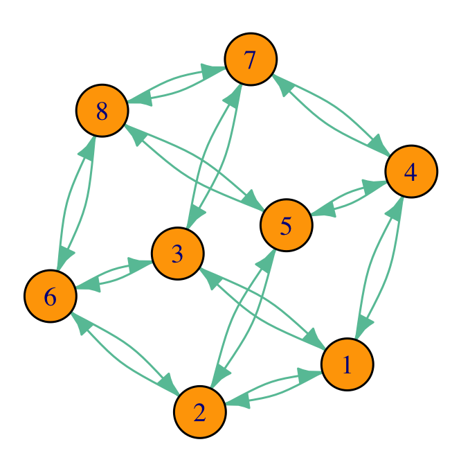

   The initial distribution is $a^{(0)}=(1,0,0,0,0,0,0,0)$ and the transition matrix looks like this:
   $$\begin{align}
   P=
   \begin{pmatrix}
   0 & \frac{1}{3} & \frac{1}{3} & \frac{1}{3} & 0 & 0
   & 0 & 0\\
   \frac{1}{3} & 0 & 0 & 0 & \frac{1}{3} & \frac{1}{3}
   & 0 & 0\\
   \frac{1}{3} & 0 & 0 & 0 & 0 & \frac{1}{3} &
   \frac{1}{3} & 0\\
   \frac{1}{3} & 0 & 0 & 0 & \frac{1}{3} & 0 &
   \frac{1}{3} & 0\\
   0 & \frac{1}{3} & 0 & \frac{1}{3} & 0 & 0 & 0
   & \frac{1}{3}\\
   0 & \frac{1}{3} & \frac{1}{3} & 0 & 0 & 0 & 0
   & \frac{1}{3}\\
   0 & 0 & \frac{1}{3} & \frac{1}{3} & 0 & 0 & 0
   & \frac{1}{3}\\
   0 & 0 & 0 & 0 & \frac{1}{3} & \frac{1}{3} &
   \frac{1}{3} & 0\\
   \end{pmatrix}
   \end{align}$$
2. First, we build the transition matrix. Copying from above we get

   ```r
   P=matrix( 1/3 * c(
     0, 1, 1, 1, 0, 0, 0, 0,
     1, 0, 0, 0, 1, 1, 0, 0,
     1, 0, 0, 0, 0, 1, 1, 0,
     1, 0, 0, 0, 1, 0, 1, 0,
     0, 1, 0, 1, 0, 0, 0, 1,
     0, 1, 1, 0, 0, 0, 0, 1,
     0, 0, 1, 1, 0, 0, 0, 1,
     0, 0, 0, 0, 1, 1, 1, 0),
   byrow = TRUE, ncol = 8)
   ```

   Then we reuse the code from the notes to build a data frame filled with simulations. The only difference is that we make it a function of the number of simulations `nsim` and the number of steps `T`, so that we can experiment with it. Since the states are already numbers from $1$ to $8$, we do not need to convert between states and row/column numbers.

   ```r
   # simulate the next position of the chain
   draw_next = function(i) {
     sample(1:8, prob = P[i, ], size = 1)
   }

   # simulate a single trajectory of length T
   # from the initial state
   single_trajectory = function(initial_state, T) {
     path = numeric(T) # vector of zeros of size T
     last = initial_state
     for (n in 1:T) {
       path[n] = draw_next(last)
       last = path[n]
     }
     return(path)
   }

   # simulate the entire chain
   simulate_chain = function(initial_state,T,nsim) {
     data.frame(X0 = initial_state,
                t(replicate(
                  nsim, single_trajectory(initial_state,T)
                )))
   }
   ```

   To see what values of `T` might work, we check how many trajectories contain the vertex $8$ for different values of `T`. The function `match` returns the first index where $8$ occurs, or `NA` if it does not. `is.na` returns `TRUE` if the argument is `NA` and false otherwise, so `!is.nan(match(8,x))` returns `TRUE` if and only if `x` contains $8$.

   ```r
   contains_eight <- function(x) {
     return(!is.na(match(8,x)))
   }

   for (T in c(10,20,30,40,50, 100)) {
     df = simulate_chain(1, T, 1000)
     print(c(T,mean(apply(df,1,contains_eight))))
   }
   ```

   ```
   ## [1] 10.000  0.612
   ## [1] 20.000  0.894
   ## [1] 30.000  0.975
   ## [1] 40.000  0.991
   ## [1] 50.000  0.997
   ## [1] 100   1
   ```

   Even though we set `nsim` to only $1000$ in this round (to speed things up), it is clear that for $T=100$, an overwhelming proportion of trajectories will hit $8$. Even $T=50$ would probably yield decent results.

   Next, we run $10000$ simulations with $T=100$ (it takes about $5$ sec on my moderately fast computer)

   ```r
   df_100 = simulate_chain(1,100,10000)
   ```

   To double check, we find how many of the trajectories here actually hit $8$:

   ```r
   mean(apply(df_100,1,contains_eight))
   ```

   ```
   ## [1] 1
   ```

   All of them. Good. Next, instead of `test` we apply a function which returns the first time $8$ appears in a sequence. The build-in `match` does exactly that (the `nomatch` argument tells it to return $101$ if $8$ is not in the input). We subtract $1$ from its value because R starts it sequences at $1$.

   ```r
   first_opposite_100 = function(x){
     return(match(8,x, nomatch=101)-1)
   }
   tau = apply(df_100,1,first_opposite_100)
   print(c(mean(tau), sd(tau)))
   ```

   ```
   ## [1] 10.127000  8.099928
   ```

   To double check our choice $T=100$, we repeat everything with $T=50$:

   ```r
   first_opposite_50 = function(x){
     return(match(8,x, nomatch=51)-1)
   }
   df_50 = simulate_chain(1,50,10000)
   tau_50 = apply(df_50,1,first_opposite_50)
   print(c(mean(tau_50), sd(tau_50)))
   ```

   ```
   ## [1] 10.029800  7.795703
   ```

   The values are sufficiently close even though we do expect about $.3\%$ of the trajectories not to hit $8$ in the first $50$ steps. Since our function `first_opposite_50` returns $51$ in those cases, we get a bit of an underestimate.

   Trying $T=200$ does not change the estimate by too much:

   ```r
   first_opposite_200 = function(x){
     return(match(8,x, nomatch=201)-1)
   }
   df_200 = simulate_chain(1,200,10000)
   tau_200 = apply(df_200,1,first_opposite_200)
   print(c(mean(tau_200), sd(tau_200)))
   ```

   ```
   ## [1] 10.036200  8.006316
   ```

   Btw, the true value for the mean is $10$. We’ll learn how to compute it analytically soon.
3. We can reuse the dataframe `df_100` from the last problem. What is new is the function we will `apply` to each row. The first time all values have been observed is known as the *cover time*. It is the maximum of the first observation (hitting) times for each individual value, the function that computes it from a given trajectory `x` might look like this:

   ```r
   cover_time = function(x) {
    tau = numeric(8) # vector of size 8
    for (i in 1:8) {
     tau[i] = match(i,x) -1
    }
     return(max(tau))
   }

   tau_cover = apply(df_100, 1, cover_time)
   print(c(mean(tau_cover), sd(tau_cover)))
   ```

   ```
   ## [1] 21.014400  9.626539
   ```

   Note that the function `match` returns a `NA` in case it does not find its target (and the option `nomatch` has not been set). If `tau_cover` had any `NA`s in it, the output of `mean` would also be a `NA`. Since it is not, we conclude that all simulated trajectories visited all eight vertices.
4. The main difficulty in the case of a hypercube of dimension $d$ is the construction of the transition matrix. In fact, already for $d=5$, the matrix is $32\times 32$, for $d=10$ it has more than a million entries and for $d=40$, the number of entries exceeds the number of stars in the known universe. Moreover, this cannot be done by hand anymore, and one would need to think a bit about where exactly to put the non-zero values in each row. The way out is not to build a matrix at all, but to simulate the chain directly. Each state looks looks $(x_1, \dots, x_d)$, where $x_i \in \{ 0,1 \}$ for each $i$, and the states that are at the distance $1$ from each other are exactly those states that differ in exactly one coordinate. Put differently, moving across an edge is equivalent to flipping one coordinate from $0$ to $1$ (or $1$ to $0$). This makes the simulation step easy - at each point in time, pick a uniform random number from $1$ to $d$ and flip the value at that coordinate. The representation of the states as vectors of zeros and ones is convenient for simulation, but not so much for further analysis (e.g., the function `match` works well only on numerical vectors). So, we will have to convert each vector to an integer before we store it. The natural way to do that is to think of each such vector as a binary representation of a number between $1$ and $2^d$. The function `vector_to_number` below does exactly that - it unpacks the binary representation of a number

   ```r
   vector_to_number = function(x) {
     power_of_two = 1
     out = 0
     for (i in 1:length(x)) {
       if (x[i] == 1) {
         out = out + power_of_two
       }
       power_of_two = power_of_two * 2
     }
     return(out+1) # to be between 1 and 2^d
   }
   ```

   The rest is almost exactly the same as before:

   ```r
   single_trajectory_hyper= function(d, T) {
     state = integer(d) # initial state (0,0,...,0)
     path = integer(T-1) # pre-allocating a vector of size T-1
     for (n in 1:(T-1)) {
       pos = sample(d,1)
       state[pos] = 1 - state[pos]
       path[n] = vector_to_number(state)
     }
     return(path)
   }

   simulate_chain_hyper= function(d,T,nsim) {
     data.frame( X0=1, # 1 corresponds to the initial state (0,0,...,0)
                 t(replicate(
                  nsim, single_trajectory_hyper(d,T)
                )))
   }
   ```

   To find the estimates associated with the first hitting time of the opposite vertex (then one with coordinates $(1,1,\dots,1)$) we can reuse the code from part 2. above with minimal adjustments.

   ```r
   first_opposite_hyper = function(x,d){
     return(match(2^d,x)-1)
   }

   hitting_time_estimates = function(d,T,nsim){
     df = simulate_chain_hyper(d,T,nsim)
     tau_hyper = apply(df,1,first_opposite_hyper, d=d)
                                             # the last argument d=d gets
                                             # passed to first_opposite_hyper
     return(c(mean(tau_hyper), sd(tau_hyper)))
   }
   ```

   As a “sanity check”, we first recompute the results for the $3$-dimensional cube

   ```r
   hitting_time_estimates(3,100,10000)
   ```

   ```
   ## [1] 9.975200 7.829835
   ```

   Next, let us try $d=4$

   ```r
   hitting_time_estimates(4,100,10000)
   ```

   ```
   ## [1] NA NA
   ```

   The `NA`s suggest that $T=100$ is too small for $d=4$, i.e., that not every trajectory hists the opposite vertex $(1,1,1,1)$. Increasing $T$ to $300$ does the trick:

   ```r
   hitting_time_estimates(4,300,10000)
   ```

   ```
   ## [1] 21.14700 18.01467
   ```

   The simulation for $d=5$ takes a bit longer, and we need $T=450$ for all trajectories to hit the opposite vertex. The extra code is there to time the execution of `hitting_time_estimates`:

   ```r
   start.time <- Sys.time()

   # actual code
   hitting_time_estimates(5,450,10000)
   ```

   ```
   ## [1] 42.01520 36.71352
   ```

   ```r
   round(Sys.time() - start.time,2)
   ```

   ```
   ## Time difference of 20.21 secs
   ```

   We stop at $d=6$; the `nsim` parameter is decreased to $5000$ for speed.

   ```r
   start.time <- Sys.time()

   # actual code
   hitting_time_estimates(6,800,5000)
   ```

   ```
   ## [1] 82.01880 75.72616
   ```

   ```r
   round(Sys.time() - start.time,2)
   ```

   ```
   ## Time difference of 18.09 secs
   ```

   Finally, we need to make a minimal adjustement to the code from 3. above to compute the cover-time estimates.

   ```r
   cover_time_hyper = function(x,d) {
    tau_cover_hyper = numeric(2^d)
    for (i in 1:2^d) {
     tau_cover_hyper[i] = match(i,x) -1
    }
     return(max(tau_cover_hyper))
   }

   cover_time_estimates= function(d,T,nsim){
     df = simulate_chain_hyper(d,T,nsim)
     tau_cover_hyper = apply(df,1,cover_time_hyper, d=d)
     return(c(mean(tau_cover_hyper), sd(tau_cover_hyper)))
   }
   ```

   We start from $d=3$

   ```r
   cover_time_estimates(3,100,10000)
   ```

   ```
   ## [1] 21.05780  9.55549
   ```

   As before, we need to increase $T$ as $d$ gets larger. Since we are waiting until *every* vertex has been visited, it may need to be even larger than in the case of the hitting time:

   ```r
   start.time <- Sys.time()

   cover_time_estimates(4,300,10000)
   ```

   ```
   ## [1] 59.46050 22.87204
   ```

   ```r
   round(Sys.time() - start.time,2)
   ```

   ```
   ## Time difference of 13.41 secs
   ```

   Then $d=5$, with `nsim` decreased to $5000$,

   ```r
   start.time <- Sys.time()

   cover_time_estimates(5,600,5000)
   ```

   ```
   ## [1] 150.28380  47.95535
   ```

   ```r
   round(Sys.time() - start.time,2)
   ```

   ```
   ## Time difference of 13.66 secs
   ```

   And, finally, $d=6$, with `nsim` set to $2000$

   ```r
   start.time <- Sys.time()

   cover_time_estimates(6,1000,2000)
   ```

   ```
   ## [1] 359.98950  99.58558
   ```

   ```r
   round(Sys.time() - start.time,2)
   ```

   ```
   ## Time difference of 9.31 secs
   ```